Saltar al contenido principal

# Paradoja de Simpson: dimensiones del pico en pingüinos

Autores/as

Allison M. Horst

Alison Presmanes Hill

Kristen B. Gorman

Fecha de publicación

17 de noviembre de 2026

**Nota**

El presente reporte tiene como objetivo ilustrar el uso de **Quarto** para comunicar resultados con fines pedagógicos a través de la base de datos `penguins` del paquete `datasets` en R base y la **Paradoja de Simpson**.

**Código**

```r
library(tidyverse)
```

# 1 Introducción

La **paradoja de Simpson** es un fenómeno estadístico en el cual una asociación observada entre 2 variables a nivel agregado se atenúa, desaparece o se invierte cuando la población se analiza por subgrupos (Simpson, 1951; Sprenger & Weinberger, 2026). En este reporte se examina este fenómeno en variables cuantitativas continuas utilizando las dimensiones del pico de los pingüinos del archipiélago Palmer (M. Horst et al., 2022).

# 2 Datos

El análisis se enfoca en 2 medidas morfométricas del pico (ver Figura 2): la longitud (`bill_len`) y la altura (`bill_dep`). Ambas medidas se encuentran expresadas en milímetros (Gorman et al., 2014).

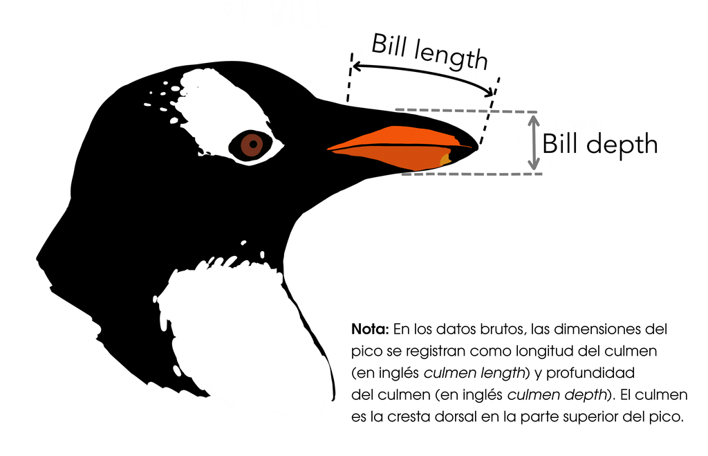

Figura 2: Dimensiones anatómicas del culmen: longitud (`bill_len`) y altura (`bill_dep`) del pico. Ilustración de Allison Horst (M. Horst et al., 2022).

En la Tabla 1 se presenta la descripción de las variables que conforman el conjunto de datos `penguins`.

Tabla 1: Variables del conjunto de datos `penguins`

| Variable | Descripción | Valores ausentes (`NA`) |
| --- | --- | --- |
| `species` | Especie de pingüino (*Adélie*, *Chinstrap*, *Gentoo*) | 0 |
| `island` | Isla del archipiélago Palmer (*Biscoe*, *Dream*, *Torgersen*) | 0 |
| `bill_len` | Longitud del culmen o pico (milímetros - mm) | 2 |
| `bill_dep` | Altura del culmen o pico (milímetros - mm) | 2 |
| `flipper_len` | Longitud de la aleta (milímetros - mm) | 2 |
| `body_mass` | Masa corporal (gramos - g) | 2 |
| `sex` | Sexo del individuo (*female*, *male*) | 11 |
| `year` | Año de estudio (2007, 2008, 2009) | 0 |

# 3 Paradoja de Simpson

El análisis de las dimensiones del pico permite ilustrar la paradoja de Simpson comparando la relación bivariada a nivel global frente al comportamiento dentro de cada especie (M. Horst et al., 2022).

## 3.1 Asociación global

Al analizar la relación entre la longitud (`bill_len`) y la altura (`bill_dep`) del pico sobre el total de pingüinos sin discriminar por especie (ver Figura 3)[^1], se observa una **pendiente negativa** estimada ($\hat{\beta}_1 = -0.0850$, $p\text{-valor} = 1.12 \times 10^{-5}$), lo que sugeriría erróneamente que a mayor longitud del pico corresponde una menor altura (M. Horst et al., 2022).

**Código**

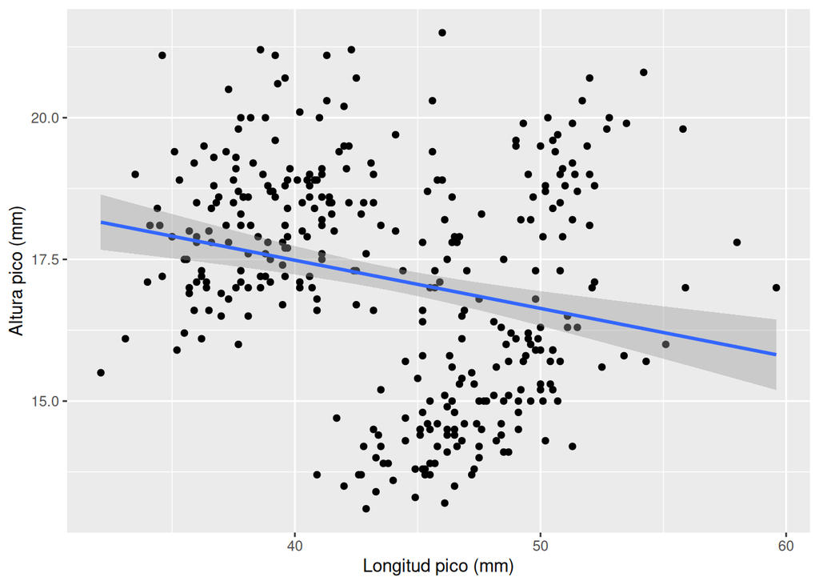

Figura 3: Asociación global entre longitud y altura del pico en pingüinos sin desagregar por especie.

```r
penguins |>
  ggplot(
    mapping = aes(
      x = bill_len,
      y = bill_dep
    )
  ) +
  geom_point() +
  geom_smooth(
    method = "lm"
  ) +
  labs(
    x = "Longitud pico (mm)",
    y = "Altura pico (mm)"
  )
```

## 3.2 Asociación por especie

**Código**

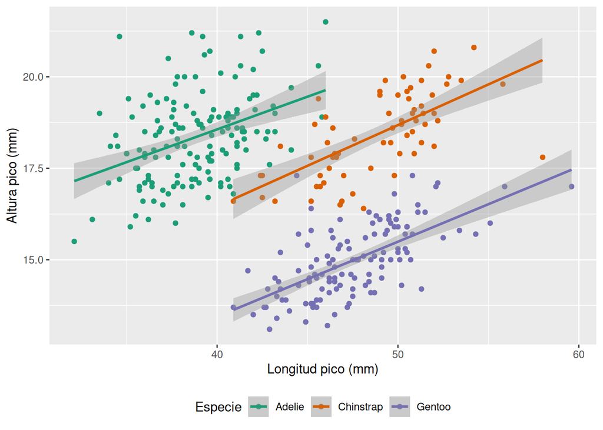

Figura 4: Asociación entre longitud y altura del pico desagregada por especie (*Adélie*, *Chinstrap*, *Gentoo*).

```r
penguins |>
  ggplot(
    mapping = aes(
      x = bill_len,
      y = bill_dep,
      color = species,
      group = species
    )
  ) +
  geom_point() +
  geom_smooth(
    method = "lm"
  ) +
  scale_color_brewer(
    type = "qual",
    palette = "Dark2"
  ) +
  labs(
    x = "Longitud pico (mm)",
    y = "Altura pico (mm)",
    color = "Especie"
  ) +
  theme(
    legend.position = "bottom"
  )
```

Esta reversión ocurre porque la especie actúa como una **variable de confusión** (en inglés *confounder*) que influye simultáneamente en ambas dimensiones del pico (Gorman et al., 2014; Sprenger & Weinberger, 2026). Los pingüinos *Adélie* poseen picos cortos y altos, mientras que los *Gentoo* tienen picos largos y de menor altura. Al omitir la especie, la recta global une los centroides de ambos grupos, generando una asociación negativa artificial (Simpson, 1951).

# 4 Conclusión

El análisis de las dimensiones del pico en los pingüinos ilustra los riesgos del análisis agregado sin estratificación (M. Horst et al., 2022). El **riesgo de agregación** demuestra que omitir variables de agrupación clave puede invertir los patrones biológicos reales de los datos y conducir a conclusiones erróneas (Simpson, 1951).

Por lo tanto, el **control por subgrupos** mediante la estratificación por variables estructurales, como la especie en el caso de `penguins`, es indispensable para una adecuada inferencia causal y modelado estadístico (Sprenger & Weinberger, 2026).

## 5 Referencias

Gorman, K. B., Williams, T. D., & Fraser, W. R. (2014). Ecological Sexual Dimorphism and Environmental Variability within a Community of Antarctic Penguins (Genus Pygoscelis). *PLoS ONE*, *9*(3), e90081. https://doi.org/10.1371/journal.pone.0090081

M. Horst, A., Presmanes Hill, A., & B. Gorman, K. (2022). Palmer Archipelago Penguins Data in the palmerpenguins R Package - An Alternative to Anderson’s Irises. *The R Journal*, *14*(1), 244-254. https://doi.org/10.32614/RJ-2022-020

Simpson, E. H. (1951). The Interpretation of Interaction in Contingency Tables. *Journal of the Royal Statistical Society Series B: Statistical Methodology*, *13*(2), 238-241. https://doi.org/10.1111/j.2517-6161.1951.tb00088.x

Sprenger, J., & Weinberger, N. (2026). Simpson’s Paradox. En E. N. Zalta & U. Nodelman (Eds.), *The Stanford Encyclopedia of Philosophy* (Summer 2026). Metaphysics Research Lab, Stanford University. https://plato.stanford.edu/archives/sum2026/entries/paradox-simpson/

## Notas

[^1]: Se eliminan 2 observaciones del gráfico porque contienen 2 valores ausentes (`NA`) en las variables `bill_len` y `bill_dep`, tal como se indica en la Tabla 1.
[^2]: Al igual que en la asociación global, se eliminan 2 observaciones del gráfico debido a los 2 valores ausentes (`NA`) presentes en `bill_len` y `bill_dep`, de acuerdo con lo reportado en la Tabla 1.